# ANOVA test for adequacao_a_proposta

Geiser C. Challco geiser@alumni.usp.br

- ANOVA: adequacao_a_proposta ~ time
  - Data Preparation
  - Summary Statistics
  - ANOVA Computation
  - PairWise Computation
- ANOVA: adequacao_a_proposta ~ time*gender + Error(id/time)
  - Data Preparation
    - Check assumptions: Identifying Outliers
    - Check assumptions: Normality Test
    - Summary Statistics
  - ANOVA Computation
  - ANOVA Computation after removing non.normal data
  - PairWise Computation
  - PairWise Computation after removing non.normal data
- ANOVA: adequacao_a_proposta ~ time*localizacao + Error(id/time)
  - Data Preparation
    - Check assumptions: Identifying Outliers
    - Check assumptions: Normality Test
    - Summary Statistics
  - ANOVA Computation
  - ANOVA Computation after removing non.normal data
  - PairWise Computation
  - PairWise Computation after removing non.normal data
- ANOVA: adequacao_a_proposta ~ time*regiao + Error(id/time)
  - Data Preparation
    - Check assumptions: Identifying Outliers
    - Check assumptions: Normality Test
    - Summary Statistics
  - ANOVA Computation
  - ANOVA Computation after removing non.normal data
  - PairWise Computation
  - PairWise Computation after removing non.normal data
- ANOVA: adequacao_a_proposta ~ time*porte + Error(id/time)
  - Data Preparation
    - Check assumptions: Identifying Outliers
    - Check assumptions: Normality Test
    - Summary Statistics
  - ANOVA Computation
  - ANOVA Computation after removing non.normal data
  - PairWise Computation
  - PairWise Computation after removing non.normal data

```r
dat <- read_excel("../data/data.xlsx", sheet = "alunos_ef14")

escolas <- read_excel("../data/data.xlsx", sheet = "escolas")
edat <- merge(dat, escolas, by = "cod_escola", all.x = T)
```

# ANOVA: adequacao_a_proposta ~ time

## Data Preparation

```r
data <- edat[,c("aluno_id","ciclo","adequacao_a_proposta")]
data$ciclo <- factor(edat$ciclo, c("Primeiro Ciclo","Segundo Ciclo",
                                   "Terceiro Ciclo","Quarto Ciclo"))

wdat <- spread(data, ciclo, adequacao_a_proposta)
wdat <- wdat[complete.cases(wdat),]
colnames(wdat) <- c("id","c1","c2","c3","c4")

ldat <- gather(wdat, key = time, value = adequacao_a_proposta, c1, c2, c3, c4) %>%
  convert_as_factor(id, time)
ldat <- rshinystatistics::remove_group_data(ldat, "adequacao_a_proposta", "time", n.limit = 30)
```

## Summary Statistics

```r
(sdat <- ldat %>% group_by(time) %>%
   get_summary_stats(adequacao_a_proposta, type = "mean_sd"))
```

```
## # A tibble: 4 × 5
##   time  variable                 n  mean    sd
##   <fct> <fct>                <dbl> <dbl> <dbl>
## 1 c1    adequacao_a_proposta  1126     3     0
## 2 c2    adequacao_a_proposta  1126     3     0
## 3 c3    adequacao_a_proposta  1126     3     0
## 4 c4    adequacao_a_proposta  1126     3     0
```

| time | variable | n | mean | sd |
| --- | --- | --- | --- | --- |
| c1 | adequacao_a_proposta | 1126 | 3 | 0 |
| c2 | adequacao_a_proposta | 1126 | 3 | 0 |
| c3 | adequacao_a_proposta | 1126 | 3 | 0 |
| c4 | adequacao_a_proposta | 1126 | 3 | 0 |

## ANOVA Computation

```r
(res.aov <- anova_test(ldat, dv = adequacao_a_proposta, wid = id, within = time))
```

```
## ANOVA Table (type III tests)
##
##   Effect DFn  DFd   F   p p<.05 ges
## 1   time   3 3375 NaN NaN  <NA>   0
```

## PairWise Computation

```r
(pwc <- ldat %>% emmeans_test(adequacao_a_proposta ~ time, detailed = T, p.adjust.method = "bonferroni"))
```

```
## # A tibble: 6 × 14
##   term  .y.          group1 group2 null.value  estimate       se    df  conf.low
## * <chr> <chr>        <chr>  <chr>       <dbl>     <dbl>    <dbl> <dbl>     <dbl>
## 1 time  adequacao_a… c1     c2              0 -1.58e-14 1.12e-14  4500 -3.76e-14
## 2 time  adequacao_a… c1     c3              0 -1.58e-14 1.12e-14  4500 -3.76e-14
## 3 time  adequacao_a… c1     c4              0 -1.58e-14 1.12e-14  4500 -3.76e-14
## 4 time  adequacao_a… c2     c3              0 -5.14e-27 1.12e-14  4500 -2.19e-14
## 5 time  adequacao_a… c2     c4              0  9.39e-27 1.12e-14  4500 -2.19e-14
## 6 time  adequacao_a… c3     c4              0  1.45e-26 1.12e-14  4500 -2.19e-14
## # ℹ 5 more variables: conf.high <dbl>, statistic <dbl>, p <dbl>, p.adj <dbl>,
## #   p.adj.signif <chr>
```

| term | .y. | group1 | group2 | null.value | estimate | se | df | conf.low | conf.high | statistic | p | p.adj | p.adj.signif |
| --- | --- | --- | --- | --- | --- | --- | --- | --- | --- | --- | --- | --- | --- |
| time | adequacao_a_proposta | c1 | c2 | 0 | 0 | 0 | 4500 | 0 | 0 | -1.414 | 0.157 | 0.944 | ns |
| time | adequacao_a_proposta | c1 | c3 | 0 | 0 | 0 | 4500 | 0 | 0 | -1.414 | 0.157 | 0.944 | ns |
| time | adequacao_a_proposta | c1 | c4 | 0 | 0 | 0 | 4500 | 0 | 0 | -1.414 | 0.157 | 0.944 | ns |
| time | adequacao_a_proposta | c2 | c3 | 0 | 0 | 0 | 4500 | 0 | 0 | 0.000 | 1.000 | 1.000 | ns |
| time | adequacao_a_proposta | c2 | c4 | 0 | 0 | 0 | 4500 | 0 | 0 | 0.000 | 1.000 | 1.000 | ns |
| time | adequacao_a_proposta | c3 | c4 | 0 | 0 | 0 | 4500 | 0 | 0 | 0.000 | 1.000 | 1.000 | ns |

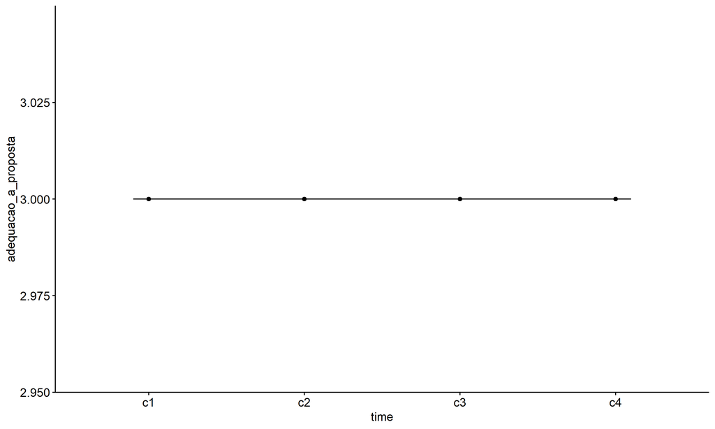

```r
pwc <- add_xy_position(pwc, x = "time", fun = "mean_se")
ggline(get_emmeans(pwc), x = "time", y = "emmean", ylab = "adequacao_a_proposta") +
  geom_errorbar(aes(ymin = conf.low, ymax = conf.high), width = 0.2) +
  stat_pvalue_manual(pwc, hide.ns = T, tip.length = F)
```

# ANOVA: adequacao_a_proposta ~ time*gender + Error(id/time)

## Data Preparation

```r
data <- edat[,c("aluno_id","gender","ciclo","adequacao_a_proposta")]
data$ciclo <- factor(data$ciclo, c("Primeiro Ciclo","Segundo Ciclo",
                                   "Terceiro Ciclo","Quarto Ciclo"))

wdat <- spread(data, ciclo, adequacao_a_proposta)
wdat <- wdat[complete.cases(wdat),]
colnames(wdat) <- c("id","gender","c1","c2","c3","c4")

ldat <- gather(wdat, key = time, value = adequacao_a_proposta, c1, c2, c3, c4) %>%
  convert_as_factor(id, time)
ldat <- remove_group_data(ldat, "adequacao_a_proposta", c("time", "gender"), n.limit = 30)
ldat$gender <- factor(ldat$gender, sort(unique(ldat$gender)))
```

### Check assumptions: Identifying Outliers

```r
outliers <- identify_outliers(group_by(ldat, time, gender), adequacao_a_proposta)
(outliers <- outliers[outliers$is.extreme == T,])
```

```
## [1] gender               time                 id
## [4] adequacao_a_proposta is.outlier           is.extreme
## <0 rows> (or 0-length row.names)
```

| gender | time | id | adequacao_a_proposta | is.outlier | is.extreme |
| --- | --- | --- | --- | --- | --- |

### Check assumptions: Normality Test

```r
(normality.df <- normality.test.per.groups(ldat, "adequacao_a_proposta", c("time", "gender")))
```

```
##                    var             variable time gender   n skewness kurtosis
## 1 adequacao_a_proposta adequacao_a_proposta   c1 Female 552        0        0
## 2 adequacao_a_proposta adequacao_a_proposta   c1   Male 513        0        0
## 3 adequacao_a_proposta adequacao_a_proposta   c2 Female 552        0        0
## 4 adequacao_a_proposta adequacao_a_proposta   c2   Male 513        0        0
## 5 adequacao_a_proposta adequacao_a_proposta   c3 Female 552        0        0
## 6 adequacao_a_proposta adequacao_a_proposta   c3   Male 513        0        0
## 7 adequacao_a_proposta adequacao_a_proposta   c4 Female 552        0        0
## 8 adequacao_a_proposta adequacao_a_proposta   c4   Male 513        0        0
##   symmetry statistic method p p.signif normality
## 1 few data        NA     NA 1       NA        NO
## 2 few data        NA     NA 1       NA        NO
## 3 few data        NA     NA 1       NA        NO
## 4 few data        NA     NA 1       NA        NO
## 5 few data        NA     NA 1       NA        NO
## 6 few data        NA     NA 1       NA        NO
## 7 few data        NA     NA 1       NA        NO
## 8 few data        NA     NA 1       NA        NO
```

| var | variable | time | gender | n | skewness | kurtosis | symmetry | statistic | method | p | p.signif | normality |
| --- | --- | --- | --- | --- | --- | --- | --- | --- | --- | --- | --- | --- |
| adequacao_a_proposta | adequacao_a_proposta | c1 | Female | 552 | 0 | 0 | few data | NA | NA | 1 | NA | NO |
| adequacao_a_proposta | adequacao_a_proposta | c1 | Male | 513 | 0 | 0 | few data | NA | NA | 1 | NA | NO |
| adequacao_a_proposta | adequacao_a_proposta | c2 | Female | 552 | 0 | 0 | few data | NA | NA | 1 | NA | NO |
| adequacao_a_proposta | adequacao_a_proposta | c2 | Male | 513 | 0 | 0 | few data | NA | NA | 1 | NA | NO |
| adequacao_a_proposta | adequacao_a_proposta | c3 | Female | 552 | 0 | 0 | few data | NA | NA | 1 | NA | NO |
| adequacao_a_proposta | adequacao_a_proposta | c3 | Male | 513 | 0 | 0 | few data | NA | NA | 1 | NA | NO |
| adequacao_a_proposta | adequacao_a_proposta | c4 | Female | 552 | 0 | 0 | few data | NA | NA | 1 | NA | NO |
| adequacao_a_proposta | adequacao_a_proposta | c4 | Male | 513 | 0 | 0 | few data | NA | NA | 1 | NA | NO |

```r
(non.ids <- unique(do.call(
  c, lapply(which(normality.df$normality == 'NO'), FUN = function(i) {
  idx = which(ldat$time == normality.df$time[i] &
                ldat$gender == normality.df$gender[i])
  getNonNormal(ldat$"adequacao_a_proposta"[idx], ldat$id[idx])
}))))
```

```r
if (length(non.ids) > 0)
  ldat2 <- ldat[!ldat$id %in% non.ids,]
```

### Summary Statistics

```r
(sdat <- ldat %>% group_by(time, gender) %>%
   get_summary_stats(adequacao_a_proposta, type = "mean_sd"))
```

```
## # A tibble: 8 × 6
##   gender time  variable                 n  mean    sd
##   <fct>  <fct> <fct>                <dbl> <dbl> <dbl>
## 1 Female c1    adequacao_a_proposta   552     3     0
## 2 Male   c1    adequacao_a_proposta   513     3     0
## 3 Female c2    adequacao_a_proposta   552     3     0
## 4 Male   c2    adequacao_a_proposta   513     3     0
## 5 Female c3    adequacao_a_proposta   552     3     0
## 6 Male   c3    adequacao_a_proposta   513     3     0
## 7 Female c4    adequacao_a_proposta   552     3     0
## 8 Male   c4    adequacao_a_proposta   513     3     0
```

| gender | time | variable | n | mean | sd |
| --- | --- | --- | --- | --- | --- |
| Female | c1 | adequacao_a_proposta | 552 | 3 | 0 |
| Male | c1 | adequacao_a_proposta | 513 | 3 | 0 |
| Female | c2 | adequacao_a_proposta | 552 | 3 | 0 |
| Male | c2 | adequacao_a_proposta | 513 | 3 | 0 |
| Female | c3 | adequacao_a_proposta | 552 | 3 | 0 |
| Male | c3 | adequacao_a_proposta | 513 | 3 | 0 |
| Female | c4 | adequacao_a_proposta | 552 | 3 | 0 |
| Male | c4 | adequacao_a_proposta | 513 | 3 | 0 |

```r
if (length(non.ids) > 0)
  (sdat <- ldat2 %>% group_by(time, gender) %>%
      get_summary_stats(adequacao_a_proposta, type = "mean_sd"))
```

| gender | time | variable | n | mean | sd |
| --- | --- | --- | --- | --- | --- |
| Female | c1 | adequacao_a_proposta | 552 | 3 | 0 |
| Male | c1 | adequacao_a_proposta | 513 | 3 | 0 |
| Female | c2 | adequacao_a_proposta | 552 | 3 | 0 |
| Male | c2 | adequacao_a_proposta | 513 | 3 | 0 |
| Female | c3 | adequacao_a_proposta | 552 | 3 | 0 |
| Male | c3 | adequacao_a_proposta | 513 | 3 | 0 |
| Female | c4 | adequacao_a_proposta | 552 | 3 | 0 |
| Male | c4 | adequacao_a_proposta | 513 | 3 | 0 |

## ANOVA Computation

```r
(res.aov <- anova_test(ldat, dv = adequacao_a_proposta, wid = id, between = gender, within = time))
```

```
## ANOVA Table (type III tests)
##
##        Effect DFn  DFd     F   p p<.05   ges
## 1      gender   1 1063 1.076 0.3       0.001
## 2        time   3 3189   NaN NaN  <NA> 0.000
## 3 gender:time   3 3189   NaN NaN  <NA> 0.000
```

## ANOVA Computation after removing non.normal data

```r
if (length(non.ids) > 0)
  (res.aov2 <- anova_test(ldat2, dv = adequacao_a_proposta, wid = id, between = gender , within = time))
```

## PairWise Computation

```r
(pwc <- ldat %>% group_by(time) %>%
   emmeans_test(adequacao_a_proposta ~ gender, detailed = T, p.adjust.method = "bonferroni"))
```

```
## # A tibble: 4 × 15
##   time  term   .y.   group1 group2 null.value  estimate       se    df  conf.low
## * <fct> <chr>  <chr> <chr>  <chr>       <dbl>     <dbl>    <dbl> <dbl>     <dbl>
## 1 c1    gender adeq… Female Male            0 -2.14e-14 1.03e-14  4252 -4.16e-14
## 2 c2    gender adeq… Female Male            0  6.02e-27 1.03e-14  4252 -2.02e-14
## 3 c3    gender adeq… Female Male            0  1.00e-26 1.03e-14  4252 -2.02e-14
## 4 c4    gender adeq… Female Male            0  8.28e-27 1.03e-14  4252 -2.02e-14
## # ℹ 5 more variables: conf.high <dbl>, statistic <dbl>, p <dbl>, p.adj <dbl>,
## #   p.adj.signif <chr>
```

| time | term | .y. | group1 | group2 | null.value | estimate | se | df | conf.low | conf.high | statistic | p | p.adj | p.adj.signif |
| --- | --- | --- | --- | --- | --- | --- | --- | --- | --- | --- | --- | --- | --- | --- |
| c1 | gender | adequacao_a_proposta | Female | Male | 0 | 0 | 0 | 4252 | 0 | 0 | -2.075 | 0.038 | 0.038 | * |
| c2 | gender | adequacao_a_proposta | Female | Male | 0 | 0 | 0 | 4252 | 0 | 0 | 0.000 | 1.000 | 1.000 | ns |
| c3 | gender | adequacao_a_proposta | Female | Male | 0 | 0 | 0 | 4252 | 0 | 0 | 0.000 | 1.000 | 1.000 | ns |
| c4 | gender | adequacao_a_proposta | Female | Male | 0 | 0 | 0 | 4252 | 0 | 0 | 0.000 | 1.000 | 1.000 | ns |

```r
(emms <- get_emmeans(pwc))
```

```
## # A tibble: 8 × 8
##   time  gender emmean       se    df conf.low conf.high method
##   <fct> <fct>   <dbl>    <dbl> <dbl>    <dbl>     <dbl> <chr>
## 1 c1    Female   3.00 7.16e-15  4252     3.00      3.00 Emmeans test
## 2 c1    Male     3.00 7.43e-15  4252     3.00      3.00 Emmeans test
## 3 c2    Female   3.00 7.16e-15  4252     3.00      3.00 Emmeans test
## 4 c2    Male     3.00 7.43e-15  4252     3.00      3.00 Emmeans test
## 5 c3    Female   3.00 7.16e-15  4252     3.00      3.00 Emmeans test
## 6 c3    Male     3.00 7.43e-15  4252     3.00      3.00 Emmeans test
## 7 c4    Female   3.00 7.16e-15  4252     3.00      3.00 Emmeans test
## 8 c4    Male     3.00 7.43e-15  4252     3.00      3.00 Emmeans test
```

| time | gender | emmean | se | df | conf.low | conf.high | method |
| --- | --- | --- | --- | --- | --- | --- | --- |
| c1 | Female | 3 | 0 | 4252 | 3 | 3 | Emmeans test |
| c1 | Male | 3 | 0 | 4252 | 3 | 3 | Emmeans test |
| c2 | Female | 3 | 0 | 4252 | 3 | 3 | Emmeans test |
| c2 | Male | 3 | 0 | 4252 | 3 | 3 | Emmeans test |
| c3 | Female | 3 | 0 | 4252 | 3 | 3 | Emmeans test |
| c3 | Male | 3 | 0 | 4252 | 3 | 3 | Emmeans test |
| c4 | Female | 3 | 0 | 4252 | 3 | 3 | Emmeans test |
| c4 | Male | 3 | 0 | 4252 | 3 | 3 | Emmeans test |

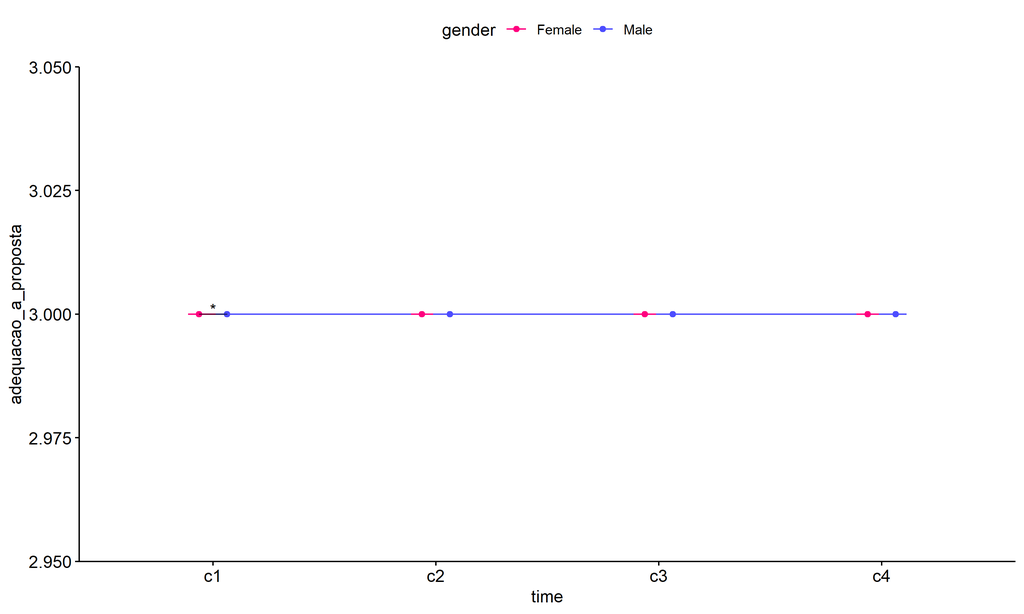

```r
pwc <- add_xy_position(pwc, x = "time", fun = "mean_se", dodge = 0.25)
pd <- position_dodge(width = 0.25)
ggline(emms, x = "time", y = "emmean", color = "gender",
       palette = c("#FF007F","#4D4DFF"),
       position = pd, ylab = "adequacao_a_proposta") +
  geom_errorbar(aes(ymin = conf.low, ymax = conf.high, color = gender),
                position = pd, width = 0.2) +
  stat_pvalue_manual(pwc, hide.ns = T, tip.length = F, linetype = 1)
```

```r
(pwc <- ldat %>% group_by(gender) %>%
    emmeans_test(adequacao_a_proposta ~ time, detailed = T, p.adjust.method = "bonferroni"))
```

```
## # A tibble: 12 × 15
##    gender term  .y.            group1 group2 null.value  estimate       se    df
##  * <fct>  <chr> <chr>          <chr>  <chr>       <dbl>     <dbl>    <dbl> <dbl>
##  1 Female time  adequacao_a_p… c1     c2              0 -2.32e-26 1.01e-14  4252
##  2 Female time  adequacao_a_p… c1     c3              0 -2.52e-26 1.01e-14  4252
##  3 Female time  adequacao_a_p… c1     c4              0 -2.96e-26 1.01e-14  4252
##  4 Female time  adequacao_a_p… c2     c3              0 -1.97e-27 1.01e-14  4252
##  5 Female time  adequacao_a_p… c2     c4              0 -6.36e-27 1.01e-14  4252
##  6 Female time  adequacao_a_p… c3     c4              0 -4.39e-27 1.01e-14  4252
##  7 Male   time  adequacao_a_p… c1     c2              0  2.14e-14 1.05e-14  4252
##  8 Male   time  adequacao_a_p… c1     c3              0  2.14e-14 1.05e-14  4252
##  9 Male   time  adequacao_a_p… c1     c4              0  2.14e-14 1.05e-14  4252
## 10 Male   time  adequacao_a_p… c2     c3              0 -3.50e-27 1.05e-14  4252
## 11 Male   time  adequacao_a_p… c2     c4              0 -9.99e-27 1.05e-14  4252
## 12 Male   time  adequacao_a_p… c3     c4              0 -6.49e-27 1.05e-14  4252
## # ℹ 6 more variables: conf.low <dbl>, conf.high <dbl>, statistic <dbl>,
## #   p <dbl>, p.adj <dbl>, p.adj.signif <chr>
```

| gender | term | .y. | group1 | group2 | null.value | estimate | se | df | conf.low | conf.high | statistic | p | p.adj | p.adj.signif |
| --- | --- | --- | --- | --- | --- | --- | --- | --- | --- | --- | --- | --- | --- | --- |
| Female | time | adequacao_a_proposta | c1 | c2 | 0 | 0 | 0 | 4252 | 0 | 0 | 0.000 | 1.000 | 1.00 | ns |
| Female | time | adequacao_a_proposta | c1 | c3 | 0 | 0 | 0 | 4252 | 0 | 0 | 0.000 | 1.000 | 1.00 | ns |
| Female | time | adequacao_a_proposta | c1 | c4 | 0 | 0 | 0 | 4252 | 0 | 0 | 0.000 | 1.000 | 1.00 | ns |
| Female | time | adequacao_a_proposta | c2 | c3 | 0 | 0 | 0 | 4252 | 0 | 0 | 0.000 | 1.000 | 1.00 | ns |
| Female | time | adequacao_a_proposta | c2 | c4 | 0 | 0 | 0 | 4252 | 0 | 0 | 0.000 | 1.000 | 1.00 | ns |
| Female | time | adequacao_a_proposta | c3 | c4 | 0 | 0 | 0 | 4252 | 0 | 0 | 0.000 | 1.000 | 1.00 | ns |
| Male | time | adequacao_a_proposta | c1 | c2 | 0 | 0 | 0 | 4252 | 0 | 0 | 2.038 | 0.042 | 0.25 | ns |
| Male | time | adequacao_a_proposta | c1 | c3 | 0 | 0 | 0 | 4252 | 0 | 0 | 2.038 | 0.042 | 0.25 | ns |
| Male | time | adequacao_a_proposta | c1 | c4 | 0 | 0 | 0 | 4252 | 0 | 0 | 2.038 | 0.042 | 0.25 | ns |
| Male | time | adequacao_a_proposta | c2 | c3 | 0 | 0 | 0 | 4252 | 0 | 0 | 0.000 | 1.000 | 1.00 | ns |
| Male | time | adequacao_a_proposta | c2 | c4 | 0 | 0 | 0 | 4252 | 0 | 0 | 0.000 | 1.000 | 1.00 | ns |
| Male | time | adequacao_a_proposta | c3 | c4 | 0 | 0 | 0 | 4252 | 0 | 0 | 0.000 | 1.000 | 1.00 | ns |

```r
(emms <- get_emmeans(pwc))
```

```
## # A tibble: 8 × 8
##   gender time  emmean       se    df conf.low conf.high method
##   <fct>  <fct>  <dbl>    <dbl> <dbl>    <dbl>     <dbl> <chr>
## 1 Female c1      3.00 7.16e-15  4252     3.00      3.00 Emmeans test
## 2 Female c2      3.00 7.16e-15  4252     3.00      3.00 Emmeans test
## 3 Female c3      3.00 7.16e-15  4252     3.00      3.00 Emmeans test
## 4 Female c4      3.00 7.16e-15  4252     3.00      3.00 Emmeans test
## 5 Male   c1      3.00 7.43e-15  4252     3.00      3.00 Emmeans test
## 6 Male   c2      3.00 7.43e-15  4252     3.00      3.00 Emmeans test
## 7 Male   c3      3.00 7.43e-15  4252     3.00      3.00 Emmeans test
## 8 Male   c4      3.00 7.43e-15  4252     3.00      3.00 Emmeans test
```

| gender | time | emmean | se | df | conf.low | conf.high | method |
| --- | --- | --- | --- | --- | --- | --- | --- |
| Female | c1 | 3 | 0 | 4252 | 3 | 3 | Emmeans test |
| Female | c2 | 3 | 0 | 4252 | 3 | 3 | Emmeans test |
| Female | c3 | 3 | 0 | 4252 | 3 | 3 | Emmeans test |
| Female | c4 | 3 | 0 | 4252 | 3 | 3 | Emmeans test |
| Male | c1 | 3 | 0 | 4252 | 3 | 3 | Emmeans test |
| Male | c2 | 3 | 0 | 4252 | 3 | 3 | Emmeans test |
| Male | c3 | 3 | 0 | 4252 | 3 | 3 | Emmeans test |
| Male | c4 | 3 | 0 | 4252 | 3 | 3 | Emmeans test |

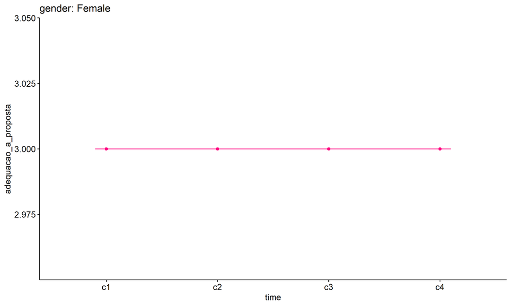

```r
emms.gg <- emms[which(emms$gender == "Female"),]
if (nrow(emms.gg) > 0)
  ggline(emms.gg, x = "time", y = "emmean", color = "#FF007F", ylab = "adequacao_a_proposta") +
    geom_errorbar(aes(ymin = conf.low, ymax = conf.high),
                  width = 0.2, color = "#FF007F") +
    stat_pvalue_manual(
      add_xy_position(pwc[which(pwc$gender == "Female"),],
                      x = "time", fun = "mean_se"),
      hide.ns = T, color = "#FF007F", tip.length = F) +
    labs(title = "gender: Female")+
    theme(legend.text = element_blank())
```

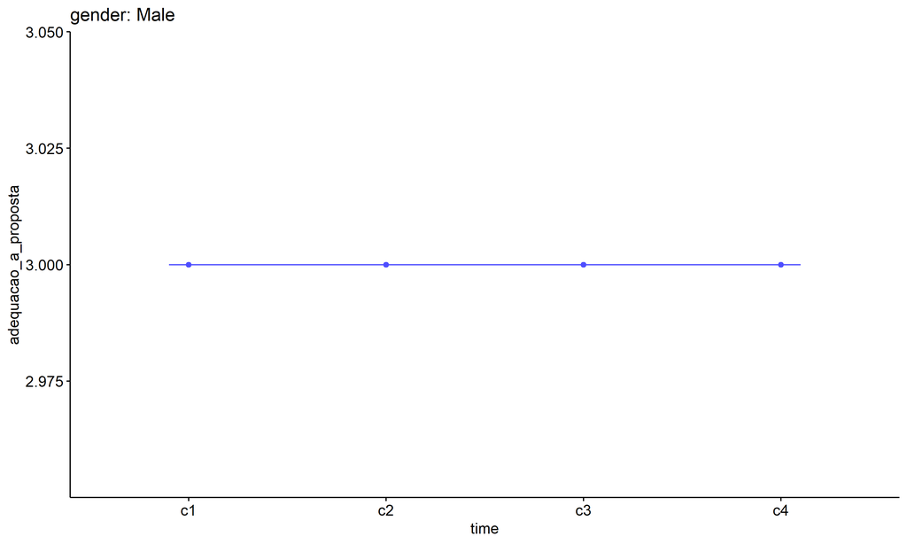

```r
emms.gg <- emms[which(emms$gender == "Male"),]
if (nrow(emms.gg) > 0)
  ggline(emms.gg, x = "time", y = "emmean", color = "#4D4DFF", ylab = "adequacao_a_proposta") +
    geom_errorbar(aes(ymin = conf.low, ymax = conf.high),
                  width = 0.2, color = "#4D4DFF") +
    stat_pvalue_manual(
      add_xy_position(pwc[which(pwc$gender == "Male"),],
                      x = "time", fun = "mean_se"),
      hide.ns = T, color = "#4D4DFF", tip.length = F) +
    labs(title = "gender: Male")+
    theme(legend.text = element_blank())
```

## PairWise Computation after removing non.normal data

```r
if (length(non.ids) > 0)
  (pwc2 <- ldat2 %>% group_by(time) %>%
     emmeans_test(adequacao_a_proposta ~ gender, detailed = T, p.adjust.method = "bonferroni"))
```

```r
if (length(non.ids) > 0)
  (emms2 <- get_emmeans(pwc2))
```

```r
if (length(non.ids) > 0) {
  pwc2 <- add_xy_position(pwc2, x = "time", fun = "mean_se", dodge = 0.25)
  pd2 <- position_dodge(width = 0.25)

  ggline(emms2, x = "time", y = "emmean", color = "gender",
         palette = c("#FF007F","#4D4DFF"),
         position = pd, ylab = "adequacao_a_proposta") +
    geom_errorbar(aes(ymin = conf.low, ymax = conf.high, color = gender),
                position = pd, width = 0.2) +
    stat_pvalue_manual(pwc2, hide.ns = T, tip.length = F, linetype = 1)
}
```

```r
if (length(non.ids) > 0)
  (pwc2 <- ldat2 %>% group_by(gender) %>%
     emmeans_test(adequacao_a_proposta ~ time, detailed = T, p.adjust.method = "bonferroni"))
```

```r
if (length(non.ids) > 0)
  (emms2 <- get_emmeans(pwc2))
```

```r
if (length(non.ids) > 0) {
  emms.gg <- emms2[which(emms2$gender == "Female"),]
  if (nrow(emms.gg) > 0)
    ggline(emms.gg, x = "time", y = "emmean", color = "#FF007F", ylab = "adequacao_a_proposta") +
    geom_errorbar(aes(ymin = conf.low, ymax = conf.high),
                  width = 0.2, color = "#FF007F") +
    stat_pvalue_manual(
      add_xy_position(pwc[which(pwc$gender == "Female"),],
                      x = "time", fun = "mean_se"),
      hide.ns = T, color = "#FF007F", tip.length = F) +
    labs(title = "gender: Female") +
    theme(legend.text = element_blank())
}
```

```r
if (length(non.ids) > 0) {
  emms.gg <- emms2[which(emms2$gender == "Male"),]
  if (nrow(emms.gg) > 0)
    ggline(emms.gg, x = "time", y = "emmean", color = "#4D4DFF", ylab = "adequacao_a_proposta") +
    geom_errorbar(aes(ymin = conf.low, ymax = conf.high),
                  width = 0.2, color = "#4D4DFF") +
    stat_pvalue_manual(
      add_xy_position(pwc[which(pwc$gender == "Male"),],
                      x = "time", fun = "mean_se"),
      hide.ns = T, color = "#4D4DFF", tip.length = F) +
    labs(title = "gender: Male") +
    theme(legend.text = element_blank())
}
```

# ANOVA: adequacao_a_proposta ~ time*localizacao + Error(id/time)

## Data Preparation

```r
data <- edat[,c("aluno_id","localizacao","ciclo","adequacao_a_proposta")]
data$ciclo <- factor(data$ciclo, c("Primeiro Ciclo","Segundo Ciclo",
                                   "Terceiro Ciclo","Quarto Ciclo"))

wdat <- spread(data, ciclo, adequacao_a_proposta)
wdat <- wdat[complete.cases(wdat),]
colnames(wdat) <- c("id","localizacao","c1","c2","c3","c4")

ldat <- gather(wdat, key = time, value = adequacao_a_proposta, c1, c2, c3, c4) %>%
  convert_as_factor(id, time)
ldat <- remove_group_data(ldat, "adequacao_a_proposta", c("time", "localizacao"), n.limit = 30)
ldat$localizacao <- factor(ldat$localizacao, sort(unique(ldat$localizacao)))
```

### Check assumptions: Identifying Outliers

```r
outliers <- identify_outliers(group_by(ldat, time, localizacao), adequacao_a_proposta)
(outliers <- outliers[outliers$is.extreme == T,])
```

```
## [1] localizacao          time                 id
## [4] adequacao_a_proposta is.outlier           is.extreme
## <0 rows> (or 0-length row.names)
```

| localizacao | time | id | adequacao_a_proposta | is.outlier | is.extreme |
| --- | --- | --- | --- | --- | --- |

### Check assumptions: Normality Test

```r
(normality.df <- normality.test.per.groups(ldat, "adequacao_a_proposta", c("time", "localizacao")))
```

```
##                    var             variable time localizacao   n skewness
## 1 adequacao_a_proposta adequacao_a_proposta   c1       Rural 181        0
## 2 adequacao_a_proposta adequacao_a_proposta   c1      Urbana 945        0
## 3 adequacao_a_proposta adequacao_a_proposta   c2       Rural 181        0
## 4 adequacao_a_proposta adequacao_a_proposta   c2      Urbana 945        0
## 5 adequacao_a_proposta adequacao_a_proposta   c3       Rural 181        0
## 6 adequacao_a_proposta adequacao_a_proposta   c3      Urbana 945        0
## 7 adequacao_a_proposta adequacao_a_proposta   c4       Rural 181        0
## 8 adequacao_a_proposta adequacao_a_proposta   c4      Urbana 945        0
##   kurtosis symmetry statistic method p p.signif normality
## 1        0 few data        NA     NA 1       NA        NO
## 2        0 few data        NA     NA 1       NA        NO
## 3        0 few data        NA     NA 1       NA        NO
## 4        0 few data        NA     NA 1       NA        NO
## 5        0 few data        NA     NA 1       NA        NO
## 6        0 few data        NA     NA 1       NA        NO
## 7        0 few data        NA     NA 1       NA        NO
## 8        0 few data        NA     NA 1       NA        NO
```

| var | variable | time | localizacao | n | skewness | kurtosis | symmetry | statistic | method | p | p.signif | normality |
| --- | --- | --- | --- | --- | --- | --- | --- | --- | --- | --- | --- | --- |
| adequacao_a_proposta | adequacao_a_proposta | c1 | Rural | 181 | 0 | 0 | few data | NA | NA | 1 | NA | NO |
| adequacao_a_proposta | adequacao_a_proposta | c1 | Urbana | 945 | 0 | 0 | few data | NA | NA | 1 | NA | NO |
| adequacao_a_proposta | adequacao_a_proposta | c2 | Rural | 181 | 0 | 0 | few data | NA | NA | 1 | NA | NO |
| adequacao_a_proposta | adequacao_a_proposta | c2 | Urbana | 945 | 0 | 0 | few data | NA | NA | 1 | NA | NO |
| adequacao_a_proposta | adequacao_a_proposta | c3 | Rural | 181 | 0 | 0 | few data | NA | NA | 1 | NA | NO |
| adequacao_a_proposta | adequacao_a_proposta | c3 | Urbana | 945 | 0 | 0 | few data | NA | NA | 1 | NA | NO |
| adequacao_a_proposta | adequacao_a_proposta | c4 | Rural | 181 | 0 | 0 | few data | NA | NA | 1 | NA | NO |
| adequacao_a_proposta | adequacao_a_proposta | c4 | Urbana | 945 | 0 | 0 | few data | NA | NA | 1 | NA | NO |

```r
(non.ids <- unique(do.call(
  c, lapply(which(normality.df$normality == 'NO'), FUN = function(i) {
  idx = which(ldat$time == normality.df$time[i] &
                ldat$localizacao == normality.df$localizacao[i])
  getNonNormal(ldat$"adequacao_a_proposta"[idx], ldat$id[idx])
}))))
```

```r
if (length(non.ids) > 0)
  ldat2 <- ldat[!ldat$id %in% non.ids,]
```

### Summary Statistics

```r
(sdat <- ldat %>% group_by(time, localizacao) %>%
   get_summary_stats(adequacao_a_proposta, type = "mean_sd"))
```

```
## # A tibble: 8 × 6
##   localizacao time  variable                 n  mean    sd
##   <fct>       <fct> <fct>                <dbl> <dbl> <dbl>
## 1 Rural       c1    adequacao_a_proposta   181     3     0
## 2 Urbana      c1    adequacao_a_proposta   945     3     0
## 3 Rural       c2    adequacao_a_proposta   181     3     0
## 4 Urbana      c2    adequacao_a_proposta   945     3     0
## 5 Rural       c3    adequacao_a_proposta   181     3     0
## 6 Urbana      c3    adequacao_a_proposta   945     3     0
## 7 Rural       c4    adequacao_a_proposta   181     3     0
## 8 Urbana      c4    adequacao_a_proposta   945     3     0
```

| localizacao | time | variable | n | mean | sd |
| --- | --- | --- | --- | --- | --- |
| Rural | c1 | adequacao_a_proposta | 181 | 3 | 0 |
| Urbana | c1 | adequacao_a_proposta | 945 | 3 | 0 |
| Rural | c2 | adequacao_a_proposta | 181 | 3 | 0 |
| Urbana | c2 | adequacao_a_proposta | 945 | 3 | 0 |
| Rural | c3 | adequacao_a_proposta | 181 | 3 | 0 |
| Urbana | c3 | adequacao_a_proposta | 945 | 3 | 0 |
| Rural | c4 | adequacao_a_proposta | 181 | 3 | 0 |
| Urbana | c4 | adequacao_a_proposta | 945 | 3 | 0 |

```r
if (length(non.ids) > 0)
  (sdat <- ldat2 %>% group_by(time, localizacao) %>%
      get_summary_stats(adequacao_a_proposta, type = "mean_sd"))
```

| localizacao | time | variable | n | mean | sd |
| --- | --- | --- | --- | --- | --- |
| Rural | c1 | adequacao_a_proposta | 181 | 3 | 0 |
| Urbana | c1 | adequacao_a_proposta | 945 | 3 | 0 |
| Rural | c2 | adequacao_a_proposta | 181 | 3 | 0 |
| Urbana | c2 | adequacao_a_proposta | 945 | 3 | 0 |
| Rural | c3 | adequacao_a_proposta | 181 | 3 | 0 |
| Urbana | c3 | adequacao_a_proposta | 945 | 3 | 0 |
| Rural | c4 | adequacao_a_proposta | 181 | 3 | 0 |
| Urbana | c4 | adequacao_a_proposta | 945 | 3 | 0 |

## ANOVA Computation

```r
(res.aov <- anova_test(ldat, dv = adequacao_a_proposta, wid = id, between = localizacao, within = time))
```

```
## ANOVA Table (type III tests)
##
##             Effect DFn  DFd     F     p p<.05     ges
## 1      localizacao   1 1124 0.191 0.662       0.00017
## 2             time   3 3372   NaN   NaN  <NA> 0.00000
## 3 localizacao:time   3 3372   NaN   NaN  <NA> 0.00000
```

## ANOVA Computation after removing non.normal data

```r
if (length(non.ids) > 0)
  (res.aov2 <- anova_test(ldat2, dv = adequacao_a_proposta, wid = id, between = localizacao , within = time))
```

## PairWise Computation

```r
(pwc <- ldat %>% group_by(time) %>%
   emmeans_test(adequacao_a_proposta ~ localizacao, detailed = T, p.adjust.method = "bonferroni"))
```

```
## # A tibble: 4 × 15
##   time  term   .y.   group1 group2 null.value  estimate       se    df  conf.low
## * <fct> <chr>  <chr> <chr>  <chr>       <dbl>     <dbl>    <dbl> <dbl>     <dbl>
## 1 c1    local… adeq… Rural  Urbana          0  1.88e-14 2.15e-14  4496 -2.33e-14
## 2 c2    local… adeq… Rural  Urbana          0 -8.72e-27 2.15e-14  4496 -4.21e-14
## 3 c3    local… adeq… Rural  Urbana          0 -4.07e-27 2.15e-14  4496 -4.21e-14
## 4 c4    local… adeq… Rural  Urbana          0 -5.41e-27 2.15e-14  4496 -4.21e-14
## # ℹ 5 more variables: conf.high <dbl>, statistic <dbl>, p <dbl>, p.adj <dbl>,
## #   p.adj.signif <chr>
```

| time | term | .y. | group1 | group2 | null.value | estimate | se | df | conf.low | conf.high | statistic | p | p.adj | p.adj.signif |
| --- | --- | --- | --- | --- | --- | --- | --- | --- | --- | --- | --- | --- | --- | --- |
| c1 | localizacao | adequacao_a_proposta | Rural | Urbana | 0 | 0 | 0 | 4496 | 0 | 0 | 0.875 | 0.382 | 0.382 | ns |
| c2 | localizacao | adequacao_a_proposta | Rural | Urbana | 0 | 0 | 0 | 4496 | 0 | 0 | 0.000 | 1.000 | 1.000 | ns |
| c3 | localizacao | adequacao_a_proposta | Rural | Urbana | 0 | 0 | 0 | 4496 | 0 | 0 | 0.000 | 1.000 | 1.000 | ns |
| c4 | localizacao | adequacao_a_proposta | Rural | Urbana | 0 | 0 | 0 | 4496 | 0 | 0 | 0.000 | 1.000 | 1.000 | ns |

```r
(emms <- get_emmeans(pwc))
```

```
## # A tibble: 8 × 8
##   time  localizacao emmean       se    df conf.low conf.high method
##   <fct> <fct>        <dbl>    <dbl> <dbl>    <dbl>     <dbl> <chr>
## 1 c1    Rural         3.00 1.97e-14  4496     3.00      3.00 Emmeans test
## 2 c1    Urbana        3.00 8.61e-15  4496     3.00      3.00 Emmeans test
## 3 c2    Rural         3.00 1.97e-14  4496     3.00      3.00 Emmeans test
## 4 c2    Urbana        3.00 8.61e-15  4496     3.00      3.00 Emmeans test
## 5 c3    Rural         3.00 1.97e-14  4496     3.00      3.00 Emmeans test
## 6 c3    Urbana        3.00 8.61e-15  4496     3.00      3.00 Emmeans test
## 7 c4    Rural         3.00 1.97e-14  4496     3.00      3.00 Emmeans test
## 8 c4    Urbana        3.00 8.61e-15  4496     3.00      3.00 Emmeans test
```

| time | localizacao | emmean | se | df | conf.low | conf.high | method |
| --- | --- | --- | --- | --- | --- | --- | --- |
| c1 | Rural | 3 | 0 | 4496 | 3 | 3 | Emmeans test |
| c1 | Urbana | 3 | 0 | 4496 | 3 | 3 | Emmeans test |
| c2 | Rural | 3 | 0 | 4496 | 3 | 3 | Emmeans test |
| c2 | Urbana | 3 | 0 | 4496 | 3 | 3 | Emmeans test |
| c3 | Rural | 3 | 0 | 4496 | 3 | 3 | Emmeans test |
| c3 | Urbana | 3 | 0 | 4496 | 3 | 3 | Emmeans test |
| c4 | Rural | 3 | 0 | 4496 | 3 | 3 | Emmeans test |
| c4 | Urbana | 3 | 0 | 4496 | 3 | 3 | Emmeans test |

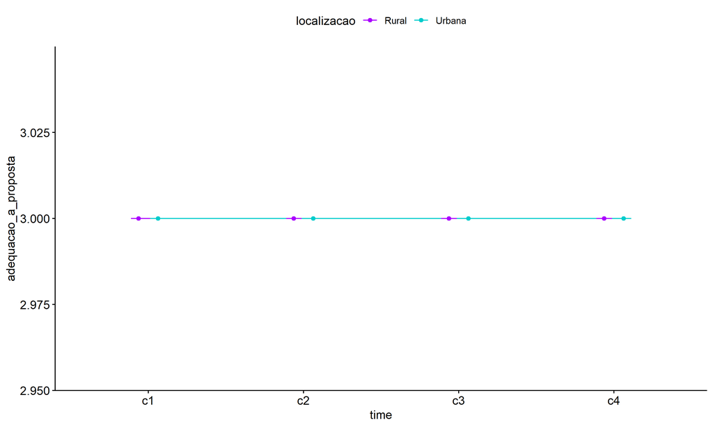

```r
pwc <- add_xy_position(pwc, x = "time", fun = "mean_se", dodge = 0.25)
pd <- position_dodge(width = 0.25)
ggline(emms, x = "time", y = "emmean", color = "localizacao",
       palette = c("#AA00FF","#00CCCC"),
       position = pd, ylab = "adequacao_a_proposta") +
  geom_errorbar(aes(ymin = conf.low, ymax = conf.high, color = localizacao),
                position = pd, width = 0.2) +
  stat_pvalue_manual(pwc, hide.ns = T, tip.length = F, linetype = 1)
```

```r
(pwc <- ldat %>% group_by(localizacao) %>%
    emmeans_test(adequacao_a_proposta ~ time, detailed = T, p.adjust.method = "bonferroni"))
```

```
## # A tibble: 12 × 15
##    localizacao term  .y.       group1 group2 null.value  estimate       se    df
##  * <fct>       <chr> <chr>     <chr>  <chr>       <dbl>     <dbl>    <dbl> <dbl>
##  1 Rural       time  adequaca… c1     c2              0  1.79e-25 2.78e-14  4496
##  2 Rural       time  adequaca… c1     c3              0  1.82e-25 2.78e-14  4496
##  3 Rural       time  adequaca… c1     c4              0  1.66e-25 2.78e-14  4496
##  4 Rural       time  adequaca… c2     c3              0  3.29e-27 2.78e-14  4496
##  5 Rural       time  adequaca… c2     c4              0 -1.26e-26 2.78e-14  4496
##  6 Rural       time  adequaca… c3     c4              0 -1.59e-26 2.78e-14  4496
##  7 Urbana      time  adequaca… c1     c2              0 -1.88e-14 1.22e-14  4496
##  8 Urbana      time  adequaca… c1     c3              0 -1.88e-14 1.22e-14  4496
##  9 Urbana      time  adequaca… c1     c4              0 -1.88e-14 1.22e-14  4496
## 10 Urbana      time  adequaca… c2     c3              0  6.69e-27 1.22e-14  4496
## 11 Urbana      time  adequaca… c2     c4              0 -1.98e-27 1.22e-14  4496
## 12 Urbana      time  adequaca… c3     c4              0 -8.68e-27 1.22e-14  4496
## # ℹ 6 more variables: conf.low <dbl>, conf.high <dbl>, statistic <dbl>,
## #   p <dbl>, p.adj <dbl>, p.adj.signif <chr>
```

| localizacao | term | .y. | group1 | group2 | null.value | estimate | se | df | conf.low | conf.high | statistic | p | p.adj | p.adj.signif |
| --- | --- | --- | --- | --- | --- | --- | --- | --- | --- | --- | --- | --- | --- | --- |
| Rural | time | adequacao_a_proposta | c1 | c2 | 0 | 0 | 0 | 4496 | 0 | 0 | 0.000 | 1.000 | 1.000 | ns |
| Rural | time | adequacao_a_proposta | c1 | c3 | 0 | 0 | 0 | 4496 | 0 | 0 | 0.000 | 1.000 | 1.000 | ns |
| Rural | time | adequacao_a_proposta | c1 | c4 | 0 | 0 | 0 | 4496 | 0 | 0 | 0.000 | 1.000 | 1.000 | ns |
| Rural | time | adequacao_a_proposta | c2 | c3 | 0 | 0 | 0 | 4496 | 0 | 0 | 0.000 | 1.000 | 1.000 | ns |
| Rural | time | adequacao_a_proposta | c2 | c4 | 0 | 0 | 0 | 4496 | 0 | 0 | 0.000 | 1.000 | 1.000 | ns |
| Rural | time | adequacao_a_proposta | c3 | c4 | 0 | 0 | 0 | 4496 | 0 | 0 | 0.000 | 1.000 | 1.000 | ns |
| Urbana | time | adequacao_a_proposta | c1 | c2 | 0 | 0 | 0 | 4496 | 0 | 0 | -1.543 | 0.123 | 0.737 | ns |
| Urbana | time | adequacao_a_proposta | c1 | c3 | 0 | 0 | 0 | 4496 | 0 | 0 | -1.543 | 0.123 | 0.737 | ns |
| Urbana | time | adequacao_a_proposta | c1 | c4 | 0 | 0 | 0 | 4496 | 0 | 0 | -1.543 | 0.123 | 0.737 | ns |
| Urbana | time | adequacao_a_proposta | c2 | c3 | 0 | 0 | 0 | 4496 | 0 | 0 | 0.000 | 1.000 | 1.000 | ns |
| Urbana | time | adequacao_a_proposta | c2 | c4 | 0 | 0 | 0 | 4496 | 0 | 0 | 0.000 | 1.000 | 1.000 | ns |
| Urbana | time | adequacao_a_proposta | c3 | c4 | 0 | 0 | 0 | 4496 | 0 | 0 | 0.000 | 1.000 | 1.000 | ns |

```r
(emms <- get_emmeans(pwc))
```

```
## # A tibble: 8 × 8
##   localizacao time  emmean       se    df conf.low conf.high method
##   <fct>       <fct>  <dbl>    <dbl> <dbl>    <dbl>     <dbl> <chr>
## 1 Rural       c1      3.00 1.97e-14  4496     3.00      3.00 Emmeans test
## 2 Rural       c2      3.00 1.97e-14  4496     3.00      3.00 Emmeans test
## 3 Rural       c3      3.00 1.97e-14  4496     3.00      3.00 Emmeans test
## 4 Rural       c4      3.00 1.97e-14  4496     3.00      3.00 Emmeans test
## 5 Urbana      c1      3.00 8.61e-15  4496     3.00      3.00 Emmeans test
## 6 Urbana      c2      3.00 8.61e-15  4496     3.00      3.00 Emmeans test
## 7 Urbana      c3      3.00 8.61e-15  4496     3.00      3.00 Emmeans test
## 8 Urbana      c4      3.00 8.61e-15  4496     3.00      3.00 Emmeans test
```

| localizacao | time | emmean | se | df | conf.low | conf.high | method |
| --- | --- | --- | --- | --- | --- | --- | --- |
| Rural | c1 | 3 | 0 | 4496 | 3 | 3 | Emmeans test |
| Rural | c2 | 3 | 0 | 4496 | 3 | 3 | Emmeans test |
| Rural | c3 | 3 | 0 | 4496 | 3 | 3 | Emmeans test |
| Rural | c4 | 3 | 0 | 4496 | 3 | 3 | Emmeans test |
| Urbana | c1 | 3 | 0 | 4496 | 3 | 3 | Emmeans test |
| Urbana | c2 | 3 | 0 | 4496 | 3 | 3 | Emmeans test |
| Urbana | c3 | 3 | 0 | 4496 | 3 | 3 | Emmeans test |
| Urbana | c4 | 3 | 0 | 4496 | 3 | 3 | Emmeans test |

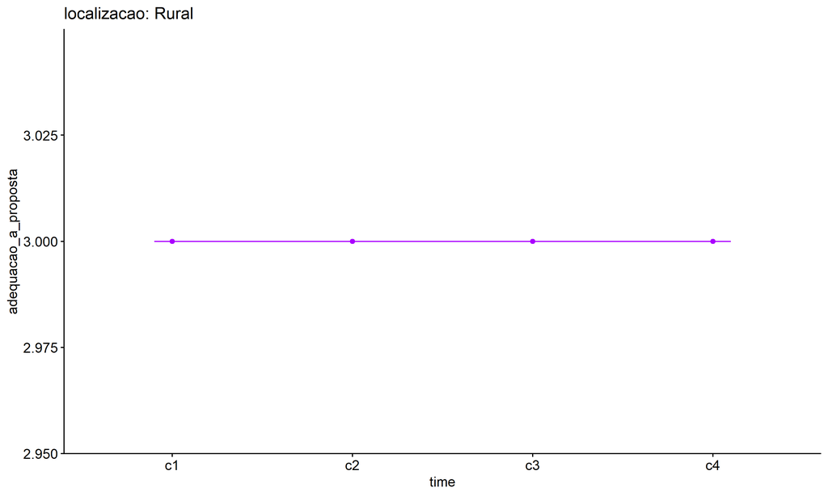

```r
emms.gg <- emms[which(emms$localizacao == "Rural"),]
if (nrow(emms.gg) > 0)
  ggline(emms.gg, x = "time", y = "emmean", color = "#AA00FF", ylab = "adequacao_a_proposta") +
    geom_errorbar(aes(ymin = conf.low, ymax = conf.high),
                  width = 0.2, color = "#AA00FF") +
    stat_pvalue_manual(
      add_xy_position(pwc[which(pwc$localizacao == "Rural"),],
                      x = "time", fun = "mean_se"),
      hide.ns = T, color = "#AA00FF", tip.length = F) +
    labs(title = "localizacao: Rural")+
    theme(legend.text = element_blank())
```

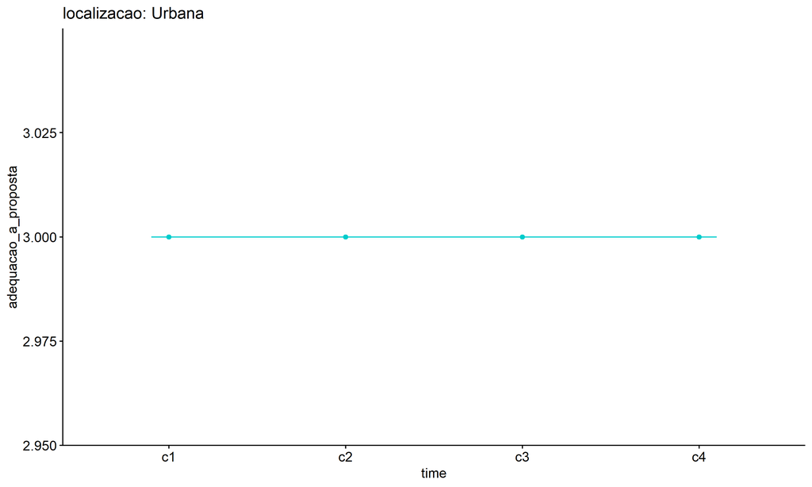

```r
emms.gg <- emms[which(emms$localizacao == "Urbana"),]
if (nrow(emms.gg) > 0)
  ggline(emms.gg, x = "time", y = "emmean", color = "#00CCCC", ylab = "adequacao_a_proposta") +
    geom_errorbar(aes(ymin = conf.low, ymax = conf.high),
                  width = 0.2, color = "#00CCCC") +
    stat_pvalue_manual(
      add_xy_position(pwc[which(pwc$localizacao == "Urbana"),],
                      x = "time", fun = "mean_se"),
      hide.ns = T, color = "#00CCCC", tip.length = F) +
    labs(title = "localizacao: Urbana")+
    theme(legend.text = element_blank())
```

## PairWise Computation after removing non.normal data

```r
if (length(non.ids) > 0)
  (pwc2 <- ldat2 %>% group_by(time) %>%
     emmeans_test(adequacao_a_proposta ~ localizacao, detailed = T, p.adjust.method = "bonferroni"))
```

```r
if (length(non.ids) > 0)
  (emms2 <- get_emmeans(pwc2))
```

```r
if (length(non.ids) > 0) {
  pwc2 <- add_xy_position(pwc2, x = "time", fun = "mean_se", dodge = 0.25)
  pd2 <- position_dodge(width = 0.25)

  ggline(emms2, x = "time", y = "emmean", color = "localizacao",
         palette = c("#AA00FF","#00CCCC"),
         position = pd, ylab = "adequacao_a_proposta") +
    geom_errorbar(aes(ymin = conf.low, ymax = conf.high, color = localizacao),
                position = pd, width = 0.2) +
    stat_pvalue_manual(pwc2, hide.ns = T, tip.length = F, linetype = 1)
}
```

```r
if (length(non.ids) > 0)
  (pwc2 <- ldat2 %>% group_by(localizacao) %>%
     emmeans_test(adequacao_a_proposta ~ time, detailed = T, p.adjust.method = "bonferroni"))
```

```r
if (length(non.ids) > 0)
  (emms2 <- get_emmeans(pwc2))
```

```r
if (length(non.ids) > 0) {
  emms.gg <- emms2[which(emms2$localizacao == "Rural"),]
  if (nrow(emms.gg) > 0)
    ggline(emms.gg, x = "time", y = "emmean", color = "#AA00FF", ylab = "adequacao_a_proposta") +
    geom_errorbar(aes(ymin = conf.low, ymax = conf.high),
                  width = 0.2, color = "#AA00FF") +
    stat_pvalue_manual(
      add_xy_position(pwc[which(pwc$localizacao == "Rural"),],
                      x = "time", fun = "mean_se"),
      hide.ns = T, color = "#AA00FF", tip.length = F) +
    labs(title = "localizacao: Rural") +
    theme(legend.text = element_blank())
}
```

```r
if (length(non.ids) > 0) {
  emms.gg <- emms2[which(emms2$localizacao == "Urbana"),]
  if (nrow(emms.gg) > 0)
    ggline(emms.gg, x = "time", y = "emmean", color = "#00CCCC", ylab = "adequacao_a_proposta") +
    geom_errorbar(aes(ymin = conf.low, ymax = conf.high),
                  width = 0.2, color = "#00CCCC") +
    stat_pvalue_manual(
      add_xy_position(pwc[which(pwc$localizacao == "Urbana"),],
                      x = "time", fun = "mean_se"),
      hide.ns = T, color = "#00CCCC", tip.length = F) +
    labs(title = "localizacao: Urbana") +
    theme(legend.text = element_blank())
}
```

# ANOVA: adequacao_a_proposta ~ time*regiao + Error(id/time)

## Data Preparation

```r
data <- edat[,c("aluno_id","regiao","ciclo","adequacao_a_proposta")]
data$ciclo <- factor(data$ciclo, c("Primeiro Ciclo","Segundo Ciclo",
                                   "Terceiro Ciclo","Quarto Ciclo"))

wdat <- spread(data, ciclo, adequacao_a_proposta)
wdat <- wdat[complete.cases(wdat),]
colnames(wdat) <- c("id","regiao","c1","c2","c3","c4")

ldat <- gather(wdat, key = time, value = adequacao_a_proposta, c1, c2, c3, c4) %>%
  convert_as_factor(id, time)
ldat <- remove_group_data(ldat, "adequacao_a_proposta", c("time", "regiao"), n.limit = 30)
ldat$regiao <- factor(ldat$regiao, sort(unique(ldat$regiao)))
```

### Check assumptions: Identifying Outliers

```r
outliers <- identify_outliers(group_by(ldat, time, regiao), adequacao_a_proposta)
(outliers <- outliers[outliers$is.extreme == T,])
```

```
## [1] regiao               time                 id
## [4] adequacao_a_proposta is.outlier           is.extreme
## <0 rows> (or 0-length row.names)
```

| regiao | time | id | adequacao_a_proposta | is.outlier | is.extreme |
| --- | --- | --- | --- | --- | --- |

### Check assumptions: Normality Test

```r
(normality.df <- normality.test.per.groups(ldat, "adequacao_a_proposta", c("time", "regiao")))
```

```
##                     var             variable time       regiao   n skewness
## 1  adequacao_a_proposta adequacao_a_proposta   c1 Centro-Oeste  48        0
## 2  adequacao_a_proposta adequacao_a_proposta   c1     Nordeste 545        0
## 3  adequacao_a_proposta adequacao_a_proposta   c1        Norte  78        0
## 4  adequacao_a_proposta adequacao_a_proposta   c1      Sudeste 393        0
## 5  adequacao_a_proposta adequacao_a_proposta   c1          Sul  62        0
## 6  adequacao_a_proposta adequacao_a_proposta   c2 Centro-Oeste  48        0
## 7  adequacao_a_proposta adequacao_a_proposta   c2     Nordeste 545        0
## 8  adequacao_a_proposta adequacao_a_proposta   c2        Norte  78        0
## 9  adequacao_a_proposta adequacao_a_proposta   c2      Sudeste 393        0
## 10 adequacao_a_proposta adequacao_a_proposta   c2          Sul  62        0
## 11 adequacao_a_proposta adequacao_a_proposta   c3 Centro-Oeste  48        0
## 12 adequacao_a_proposta adequacao_a_proposta   c3     Nordeste 545        0
## 13 adequacao_a_proposta adequacao_a_proposta   c3        Norte  78        0
## 14 adequacao_a_proposta adequacao_a_proposta   c3      Sudeste 393        0
```

[output cut: 27 more lines]

| var | variable | time | regiao | n | skewness | kurtosis | symmetry | statistic | method | p | p.signif | normality |
| --- | --- | --- | --- | --- | --- | --- | --- | --- | --- | --- | --- | --- |
| adequacao_a_proposta | adequacao_a_proposta | c1 | Centro-Oeste | 48 | 0 | 0 | few data | NA | NA | 1 | NA | NO |
| adequacao_a_proposta | adequacao_a_proposta | c1 | Nordeste | 545 | 0 | 0 | few data | NA | NA | 1 | NA | NO |
| adequacao_a_proposta | adequacao_a_proposta | c1 | Norte | 78 | 0 | 0 | few data | NA | NA | 1 | NA | NO |
| adequacao_a_proposta | adequacao_a_proposta | c1 | Sudeste | 393 | 0 | 0 | few data | NA | NA | 1 | NA | NO |
| adequacao_a_proposta | adequacao_a_proposta | c1 | Sul | 62 | 0 | 0 | few data | NA | NA | 1 | NA | NO |
| adequacao_a_proposta | adequacao_a_proposta | c2 | Centro-Oeste | 48 | 0 | 0 | few data | NA | NA | 1 | NA | NO |
| adequacao_a_proposta | adequacao_a_proposta | c2 | Nordeste | 545 | 0 | 0 | few data | NA | NA | 1 | NA | NO |
| adequacao_a_proposta | adequacao_a_proposta | c2 | Norte | 78 | 0 | 0 | few data | NA | NA | 1 | NA | NO |
| adequacao_a_proposta | adequacao_a_proposta | c2 | Sudeste | 393 | 0 | 0 | few data | NA | NA | 1 | NA | NO |
| adequacao_a_proposta | adequacao_a_proposta | c2 | Sul | 62 | 0 | 0 | few data | NA | NA | 1 | NA | NO |
| adequacao_a_proposta | adequacao_a_proposta | c3 | Centro-Oeste | 48 | 0 | 0 | few data | NA | NA | 1 | NA | NO |
| adequacao_a_proposta | adequacao_a_proposta | c3 | Nordeste | 545 | 0 | 0 | few data | NA | NA | 1 | NA | NO |
| adequacao_a_proposta | adequacao_a_proposta | c3 | Norte | 78 | 0 | 0 | few data | NA | NA | 1 | NA | NO |
| adequacao_a_proposta | adequacao_a_proposta | c3 | Sudeste | 393 | 0 | 0 | few data | NA | NA | 1 | NA | NO |
| adequacao_a_proposta | adequacao_a_proposta | c3 | Sul | 62 | 0 | 0 | few data | NA | NA | 1 | NA | NO |
| adequacao_a_proposta | adequacao_a_proposta | c4 | Centro-Oeste | 48 | 0 | 0 | few data | NA | NA | 1 | NA | NO |
| adequacao_a_proposta | adequacao_a_proposta | c4 | Nordeste | 545 | 0 | 0 | few data | NA | NA | 1 | NA | NO |
| adequacao_a_proposta | adequacao_a_proposta | c4 | Norte | 78 | 0 | 0 | few data | NA | NA | 1 | NA | NO |
| adequacao_a_proposta | adequacao_a_proposta | c4 | Sudeste | 393 | 0 | 0 | few data | NA | NA | 1 | NA | NO |
| adequacao_a_proposta | adequacao_a_proposta | c4 | Sul | 62 | 0 | 0 | few data | NA | NA | 1 | NA | NO |

```r
(non.ids <- unique(do.call(
  c, lapply(which(normality.df$normality == 'NO'), FUN = function(i) {
  idx = which(ldat$time == normality.df$time[i] &
                ldat$regiao == normality.df$regiao[i])
  getNonNormal(ldat$"adequacao_a_proposta"[idx], ldat$id[idx])
}))))
```

```r
if (length(non.ids) > 0)
  ldat2 <- ldat[!ldat$id %in% non.ids,]
```

### Summary Statistics

```r
(sdat <- ldat %>% group_by(time, regiao) %>%
   get_summary_stats(adequacao_a_proposta, type = "mean_sd"))
```

```
## # A tibble: 20 × 6
##    regiao       time  variable                 n  mean    sd
##    <fct>        <fct> <fct>                <dbl> <dbl> <dbl>
##  1 Centro-Oeste c1    adequacao_a_proposta    48     3     0
##  2 Nordeste     c1    adequacao_a_proposta   545     3     0
##  3 Norte        c1    adequacao_a_proposta    78     3     0
##  4 Sudeste      c1    adequacao_a_proposta   393     3     0
##  5 Sul          c1    adequacao_a_proposta    62     3     0
##  6 Centro-Oeste c2    adequacao_a_proposta    48     3     0
##  7 Nordeste     c2    adequacao_a_proposta   545     3     0
##  8 Norte        c2    adequacao_a_proposta    78     3     0
##  9 Sudeste      c2    adequacao_a_proposta   393     3     0
## 10 Sul          c2    adequacao_a_proposta    62     3     0
## 11 Centro-Oeste c3    adequacao_a_proposta    48     3     0
## 12 Nordeste     c3    adequacao_a_proposta   545     3     0
## 13 Norte        c3    adequacao_a_proposta    78     3     0
## 14 Sudeste      c3    adequacao_a_proposta   393     3     0
## 15 Sul          c3    adequacao_a_proposta    62     3     0
## 16 Centro-Oeste c4    adequacao_a_proposta    48     3     0
## 17 Nordeste     c4    adequacao_a_proposta   545     3     0
## 18 Norte        c4    adequacao_a_proposta    78     3     0
## 19 Sudeste      c4    adequacao_a_proposta   393     3     0
## 20 Sul          c4    adequacao_a_proposta    62     3     0
```

| regiao | time | variable | n | mean | sd |
| --- | --- | --- | --- | --- | --- |
| Centro-Oeste | c1 | adequacao_a_proposta | 48 | 3 | 0 |
| Nordeste | c1 | adequacao_a_proposta | 545 | 3 | 0 |
| Norte | c1 | adequacao_a_proposta | 78 | 3 | 0 |
| Sudeste | c1 | adequacao_a_proposta | 393 | 3 | 0 |
| Sul | c1 | adequacao_a_proposta | 62 | 3 | 0 |
| Centro-Oeste | c2 | adequacao_a_proposta | 48 | 3 | 0 |
| Nordeste | c2 | adequacao_a_proposta | 545 | 3 | 0 |
| Norte | c2 | adequacao_a_proposta | 78 | 3 | 0 |
| Sudeste | c2 | adequacao_a_proposta | 393 | 3 | 0 |
| Sul | c2 | adequacao_a_proposta | 62 | 3 | 0 |
| Centro-Oeste | c3 | adequacao_a_proposta | 48 | 3 | 0 |
| Nordeste | c3 | adequacao_a_proposta | 545 | 3 | 0 |
| Norte | c3 | adequacao_a_proposta | 78 | 3 | 0 |
| Sudeste | c3 | adequacao_a_proposta | 393 | 3 | 0 |
| Sul | c3 | adequacao_a_proposta | 62 | 3 | 0 |
| Centro-Oeste | c4 | adequacao_a_proposta | 48 | 3 | 0 |
| Nordeste | c4 | adequacao_a_proposta | 545 | 3 | 0 |
| Norte | c4 | adequacao_a_proposta | 78 | 3 | 0 |
| Sudeste | c4 | adequacao_a_proposta | 393 | 3 | 0 |
| Sul | c4 | adequacao_a_proposta | 62 | 3 | 0 |

```r
if (length(non.ids) > 0)
  (sdat <- ldat2 %>% group_by(time, regiao) %>%
      get_summary_stats(adequacao_a_proposta, type = "mean_sd"))
```

| regiao | time | variable | n | mean | sd |
| --- | --- | --- | --- | --- | --- |
| Centro-Oeste | c1 | adequacao_a_proposta | 48 | 3 | 0 |
| Nordeste | c1 | adequacao_a_proposta | 545 | 3 | 0 |
| Norte | c1 | adequacao_a_proposta | 78 | 3 | 0 |
| Sudeste | c1 | adequacao_a_proposta | 393 | 3 | 0 |
| Sul | c1 | adequacao_a_proposta | 62 | 3 | 0 |
| Centro-Oeste | c2 | adequacao_a_proposta | 48 | 3 | 0 |
| Nordeste | c2 | adequacao_a_proposta | 545 | 3 | 0 |
| Norte | c2 | adequacao_a_proposta | 78 | 3 | 0 |
| Sudeste | c2 | adequacao_a_proposta | 393 | 3 | 0 |
| Sul | c2 | adequacao_a_proposta | 62 | 3 | 0 |
| Centro-Oeste | c3 | adequacao_a_proposta | 48 | 3 | 0 |
| Nordeste | c3 | adequacao_a_proposta | 545 | 3 | 0 |
| Norte | c3 | adequacao_a_proposta | 78 | 3 | 0 |
| Sudeste | c3 | adequacao_a_proposta | 393 | 3 | 0 |
| Sul | c3 | adequacao_a_proposta | 62 | 3 | 0 |
| Centro-Oeste | c4 | adequacao_a_proposta | 48 | 3 | 0 |
| Nordeste | c4 | adequacao_a_proposta | 545 | 3 | 0 |
| Norte | c4 | adequacao_a_proposta | 78 | 3 | 0 |
| Sudeste | c4 | adequacao_a_proposta | 393 | 3 | 0 |
| Sul | c4 | adequacao_a_proposta | 62 | 3 | 0 |

## ANOVA Computation

```r
(res.aov <- anova_test(ldat, dv = adequacao_a_proposta, wid = id, between = regiao, within = time))
```

```
## ANOVA Table (type III tests)
##
##        Effect DFn  DFd     F   p p<.05      ges
## 1      regiao   4 1121 0.266 0.9       0.000948
## 2        time   3 3363   NaN NaN  <NA> 0.000000
## 3 regiao:time  12 3363   NaN NaN  <NA> 0.000000
```

## ANOVA Computation after removing non.normal data

```r
if (length(non.ids) > 0)
  (res.aov2 <- anova_test(ldat2, dv = adequacao_a_proposta, wid = id, between = regiao , within = time))
```

## PairWise Computation

```r
(pwc <- ldat %>% group_by(time) %>%
   emmeans_test(adequacao_a_proposta ~ regiao, detailed = T, p.adjust.method = "bonferroni"))
```

| time | term | .y. | group1 | group2 | null.value | estimate | se | df | conf.low | conf.high | statistic | p | p.adj | p.adj.signif |
| --- | --- | --- | --- | --- | --- | --- | --- | --- | --- | --- | --- | --- | --- | --- |
| c1 | regiao | adequacao_a_proposta | Centro | Oeste | 0 | 0 | 0 | 4484 | 0 | 0 | 0.817 | 0.414 | 1.000 | ns |
| c1 | regiao | adequacao_a_proposta | Centro | Oeste | 0 | 0 | 0 | 4484 | 0 | 0 | 0.000 | 1.000 | 1.000 | ns |
| c1 | regiao | adequacao_a_proposta | Centro | Oeste | 0 | 0 | 0 | 4484 | 0 | 0 | 0.000 | 1.000 | 1.000 | ns |
| c1 | regiao | adequacao_a_proposta | Centro | Oeste | 0 | 0 | 0 | 4484 | 0 | 0 | 0.000 | 1.000 | 1.000 | ns |
| c1 | regiao | adequacao_a_proposta | Nordeste | Norte | 0 | 0 | 0 | 4484 | 0 | 0 | -1.016 | 0.310 | 1.000 | ns |
| c1 | regiao | adequacao_a_proposta | Nordeste | Sudeste | 0 | 0 | 0 | 4484 | 0 | 0 | -1.858 | 0.063 | 0.632 | ns |
| c1 | regiao | adequacao_a_proposta | Nordeste | Sul | 0 | 0 | 0 | 4484 | 0 | 0 | -0.918 | 0.359 | 1.000 | ns |
| c1 | regiao | adequacao_a_proposta | Norte | Sudeste | 0 | 0 | 0 | 4484 | 0 | 0 | 0.000 | 1.000 | 1.000 | ns |
| c1 | regiao | adequacao_a_proposta | Norte | Sul | 0 | 0 | 0 | 4484 | 0 | 0 | 0.000 | 1.000 | 1.000 | ns |
| c1 | regiao | adequacao_a_proposta | Sudeste | Sul | 0 | 0 | 0 | 4484 | 0 | 0 | 0.000 | 1.000 | 1.000 | ns |
| c2 | regiao | adequacao_a_proposta | Centro | Oeste | 0 | 0 | 0 | 4484 | 0 | 0 | 0.000 | 1.000 | 1.000 | ns |
| c2 | regiao | adequacao_a_proposta | Centro | Oeste | 0 | 0 | 0 | 4484 | 0 | 0 | 0.000 | 1.000 | 1.000 | ns |
| c2 | regiao | adequacao_a_proposta | Centro | Oeste | 0 | 0 | 0 | 4484 | 0 | 0 | 0.000 | 1.000 | 1.000 | ns |
| c2 | regiao | adequacao_a_proposta | Centro | Oeste | 0 | 0 | 0 | 4484 | 0 | 0 | 0.000 | 1.000 | 1.000 | ns |
| c2 | regiao | adequacao_a_proposta | Nordeste | Norte | 0 | 0 | 0 | 4484 | 0 | 0 | 0.000 | 1.000 | 1.000 | ns |
| c2 | regiao | adequacao_a_proposta | Nordeste | Sudeste | 0 | 0 | 0 | 4484 | 0 | 0 | 0.000 | 1.000 | 1.000 | ns |
| c2 | regiao | adequacao_a_proposta | Nordeste | Sul | 0 | 0 | 0 | 4484 | 0 | 0 | 0.000 | 1.000 | 1.000 | ns |
| c2 | regiao | adequacao_a_proposta | Norte | Sudeste | 0 | 0 | 0 | 4484 | 0 | 0 | 0.000 | 1.000 | 1.000 | ns |
| c2 | regiao | adequacao_a_proposta | Norte | Sul | 0 | 0 | 0 | 4484 | 0 | 0 | 0.000 | 1.000 | 1.000 | ns |
| c2 | regiao | adequacao_a_proposta | Sudeste | Sul | 0 | 0 | 0 | 4484 | 0 | 0 | 0.000 | 1.000 | 1.000 | ns |
| c3 | regiao | adequacao_a_proposta | Centro | Oeste | 0 | 0 | 0 | 4484 | 0 | 0 | 0.000 | 1.000 | 1.000 | ns |
| c3 | regiao | adequacao_a_proposta | Centro | Oeste | 0 | 0 | 0 | 4484 | 0 | 0 | 0.000 | 1.000 | 1.000 | ns |
| c3 | regiao | adequacao_a_proposta | Centro | Oeste | 0 | 0 | 0 | 4484 | 0 | 0 | 0.000 | 1.000 | 1.000 | ns |
| c3 | regiao | adequacao_a_proposta | Centro | Oeste | 0 | 0 | 0 | 4484 | 0 | 0 | 0.000 | 1.000 | 1.000 | ns |
| c3 | regiao | adequacao_a_proposta | Nordeste | Norte | 0 | 0 | 0 | 4484 | 0 | 0 | 0.000 | 1.000 | 1.000 | ns |
| c3 | regiao | adequacao_a_proposta | Nordeste | Sudeste | 0 | 0 | 0 | 4484 | 0 | 0 | 0.000 | 1.000 | 1.000 | ns |
| c3 | regiao | adequacao_a_proposta | Nordeste | Sul | 0 | 0 | 0 | 4484 | 0 | 0 | 0.000 | 1.000 | 1.000 | ns |
| c3 | regiao | adequacao_a_proposta | Norte | Sudeste | 0 | 0 | 0 | 4484 | 0 | 0 | 0.000 | 1.000 | 1.000 | ns |
| c3 | regiao | adequacao_a_proposta | Norte | Sul | 0 | 0 | 0 | 4484 | 0 | 0 | 0.000 | 1.000 | 1.000 | ns |
| c3 | regiao | adequacao_a_proposta | Sudeste | Sul | 0 | 0 | 0 | 4484 | 0 | 0 | 0.000 | 1.000 | 1.000 | ns |
| c4 | regiao | adequacao_a_proposta | Centro | Oeste | 0 | 0 | 0 | 4484 | 0 | 0 | 0.000 | 1.000 | 1.000 | ns |
| c4 | regiao | adequacao_a_proposta | Centro | Oeste | 0 | 0 | 0 | 4484 | 0 | 0 | 0.000 | 1.000 | 1.000 | ns |
| c4 | regiao | adequacao_a_proposta | Centro | Oeste | 0 | 0 | 0 | 4484 | 0 | 0 | 0.000 | 1.000 | 1.000 | ns |
| c4 | regiao | adequacao_a_proposta | Centro | Oeste | 0 | 0 | 0 | 4484 | 0 | 0 | 0.000 | 1.000 | 1.000 | ns |
| c4 | regiao | adequacao_a_proposta | Nordeste | Norte | 0 | 0 | 0 | 4484 | 0 | 0 | 0.000 | 1.000 | 1.000 | ns |
| c4 | regiao | adequacao_a_proposta | Nordeste | Sudeste | 0 | 0 | 0 | 4484 | 0 | 0 | 0.000 | 1.000 | 1.000 | ns |
| c4 | regiao | adequacao_a_proposta | Nordeste | Sul | 0 | 0 | 0 | 4484 | 0 | 0 | 0.000 | 1.000 | 1.000 | ns |
| c4 | regiao | adequacao_a_proposta | Norte | Sudeste | 0 | 0 | 0 | 4484 | 0 | 0 | 0.000 | 1.000 | 1.000 | ns |
| c4 | regiao | adequacao_a_proposta | Norte | Sul | 0 | 0 | 0 | 4484 | 0 | 0 | 0.000 | 1.000 | 1.000 | ns |
| c4 | regiao | adequacao_a_proposta | Sudeste | Sul | 0 | 0 | 0 | 4484 | 0 | 0 | 0.000 | 1.000 | 1.000 | ns |

```r
(emms <- get_emmeans(pwc))
```

```
## # A tibble: 20 × 8
##    time  regiao       emmean       se    df conf.low conf.high method
##    <fct> <fct>         <dbl>    <dbl> <dbl>    <dbl>     <dbl> <chr>
##  1 c1    Centro-Oeste   3.00 3.83e-14  4484     3.00      3.00 Emmeans test
##  2 c1    Nordeste       3.00 1.14e-14  4484     3.00      3.00 Emmeans test
##  3 c1    Norte          3.00 3.00e-14  4484     3.00      3.00 Emmeans test
##  4 c1    Sudeste        3.00 1.34e-14  4484     3.00      3.00 Emmeans test
##  5 c1    Sul            3.00 3.37e-14  4484     3.00      3.00 Emmeans test
##  6 c2    Centro-Oeste   3.00 3.83e-14  4484     3.00      3.00 Emmeans test
##  7 c2    Nordeste       3.00 1.14e-14  4484     3.00      3.00 Emmeans test
##  8 c2    Norte          3.00 3.00e-14  4484     3.00      3.00 Emmeans test
##  9 c2    Sudeste        3.00 1.34e-14  4484     3.00      3.00 Emmeans test
## 10 c2    Sul            3.00 3.37e-14  4484     3.00      3.00 Emmeans test
## 11 c3    Centro-Oeste   3.00 3.83e-14  4484     3.00      3.00 Emmeans test
## 12 c3    Nordeste       3.00 1.14e-14  4484     3.00      3.00 Emmeans test
## 13 c3    Norte          3.00 3.00e-14  4484     3.00      3.00 Emmeans test
## 14 c3    Sudeste        3.00 1.34e-14  4484     3.00      3.00 Emmeans test
## 15 c3    Sul            3.00 3.37e-14  4484     3.00      3.00 Emmeans test
## 16 c4    Centro-Oeste   3.00 3.83e-14  4484     3.00      3.00 Emmeans test
## 17 c4    Nordeste       3.00 1.14e-14  4484     3.00      3.00 Emmeans test
## 18 c4    Norte          3.00 3.00e-14  4484     3.00      3.00 Emmeans test
## 19 c4    Sudeste        3.00 1.34e-14  4484     3.00      3.00 Emmeans test
## 20 c4    Sul            3.00 3.37e-14  4484     3.00      3.00 Emmeans test
```

| time | regiao | emmean | se | df | conf.low | conf.high | method |
| --- | --- | --- | --- | --- | --- | --- | --- |
| c1 | Centro-Oeste | 3 | 0 | 4484 | 3 | 3 | Emmeans test |
| c1 | Nordeste | 3 | 0 | 4484 | 3 | 3 | Emmeans test |
| c1 | Norte | 3 | 0 | 4484 | 3 | 3 | Emmeans test |
| c1 | Sudeste | 3 | 0 | 4484 | 3 | 3 | Emmeans test |
| c1 | Sul | 3 | 0 | 4484 | 3 | 3 | Emmeans test |
| c2 | Centro-Oeste | 3 | 0 | 4484 | 3 | 3 | Emmeans test |
| c2 | Nordeste | 3 | 0 | 4484 | 3 | 3 | Emmeans test |
| c2 | Norte | 3 | 0 | 4484 | 3 | 3 | Emmeans test |
| c2 | Sudeste | 3 | 0 | 4484 | 3 | 3 | Emmeans test |
| c2 | Sul | 3 | 0 | 4484 | 3 | 3 | Emmeans test |
| c3 | Centro-Oeste | 3 | 0 | 4484 | 3 | 3 | Emmeans test |
| c3 | Nordeste | 3 | 0 | 4484 | 3 | 3 | Emmeans test |
| c3 | Norte | 3 | 0 | 4484 | 3 | 3 | Emmeans test |
| c3 | Sudeste | 3 | 0 | 4484 | 3 | 3 | Emmeans test |
| c3 | Sul | 3 | 0 | 4484 | 3 | 3 | Emmeans test |
| c4 | Centro-Oeste | 3 | 0 | 4484 | 3 | 3 | Emmeans test |
| c4 | Nordeste | 3 | 0 | 4484 | 3 | 3 | Emmeans test |
| c4 | Norte | 3 | 0 | 4484 | 3 | 3 | Emmeans test |
| c4 | Sudeste | 3 | 0 | 4484 | 3 | 3 | Emmeans test |
| c4 | Sul | 3 | 0 | 4484 | 3 | 3 | Emmeans test |

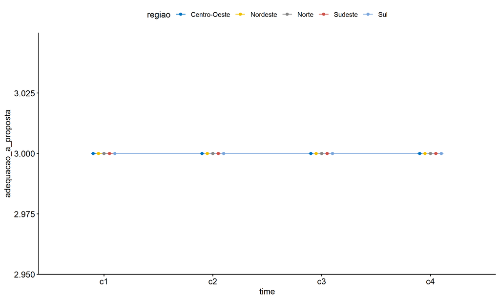

```r
pwc <- add_xy_position(pwc, x = "time", fun = "mean_se", dodge = 0.25)
pd <- position_dodge(width = 0.25)
ggline(emms, x = "time", y = "emmean", color = "regiao",
       palette = c("#0073C2FF","#EFC000FF","#868686FF","#CD534CFF","#7AA6DCFF"),
       position = pd, ylab = "adequacao_a_proposta") +
  geom_errorbar(aes(ymin = conf.low, ymax = conf.high, color = regiao),
                position = pd, width = 0.2) +
  stat_pvalue_manual(pwc, hide.ns = T, tip.length = F, linetype = 1)
```

```r
(pwc <- ldat %>% group_by(regiao) %>%
    emmeans_test(adequacao_a_proposta ~ time, detailed = T, p.adjust.method = "bonferroni"))
```

```
## # A tibble: 30 × 15
##    regiao       term  .y.      group1 group2 null.value  estimate       se    df
##  * <fct>        <chr> <chr>    <chr>  <chr>       <dbl>     <dbl>    <dbl> <dbl>
##  1 Centro-Oeste time  adequac… c1     c2              0  9.33e-25 5.41e-14  4484
##  2 Centro-Oeste time  adequac… c1     c3              0  9.33e-25 5.41e-14  4484
##  3 Centro-Oeste time  adequac… c1     c4              0  9.26e-25 5.41e-14  4484
##  4 Centro-Oeste time  adequac… c2     c3              0  2.38e-29 5.41e-14  4484
##  5 Centro-Oeste time  adequac… c2     c4              0 -7.53e-27 5.41e-14  4484
##  6 Centro-Oeste time  adequac… c3     c4              0 -7.55e-27 5.41e-14  4484
##  7 Nordeste     time  adequac… c1     c2              0 -3.26e-14 1.61e-14  4484
##  8 Nordeste     time  adequac… c1     c3              0 -3.26e-14 1.61e-14  4484
##  9 Nordeste     time  adequac… c1     c4              0 -3.26e-14 1.61e-14  4484
## 10 Nordeste     time  adequac… c2     c3              0  1.01e-27 1.61e-14  4484
## # ℹ 20 more rows
## # ℹ 6 more variables: conf.low <dbl>, conf.high <dbl>, statistic <dbl>,
## #   p <dbl>, p.adj <dbl>, p.adj.signif <chr>
```

| regiao | term | .y. | group1 | group2 | null.value | estimate | se | df | conf.low | conf.high | statistic | p | p.adj | p.adj.signif |
| --- | --- | --- | --- | --- | --- | --- | --- | --- | --- | --- | --- | --- | --- | --- |
| Centro-Oeste | time | adequacao_a_proposta | c1 | c2 | 0 | 0 | 0 | 4484 | 0 | 0 | 0.00 | 1.000 | 1.000 | ns |
| Centro-Oeste | time | adequacao_a_proposta | c1 | c3 | 0 | 0 | 0 | 4484 | 0 | 0 | 0.00 | 1.000 | 1.000 | ns |
| Centro-Oeste | time | adequacao_a_proposta | c1 | c4 | 0 | 0 | 0 | 4484 | 0 | 0 | 0.00 | 1.000 | 1.000 | ns |
| Centro-Oeste | time | adequacao_a_proposta | c2 | c3 | 0 | 0 | 0 | 4484 | 0 | 0 | 0.00 | 1.000 | 1.000 | ns |
| Centro-Oeste | time | adequacao_a_proposta | c2 | c4 | 0 | 0 | 0 | 4484 | 0 | 0 | 0.00 | 1.000 | 1.000 | ns |
| Centro-Oeste | time | adequacao_a_proposta | c3 | c4 | 0 | 0 | 0 | 4484 | 0 | 0 | 0.00 | 1.000 | 1.000 | ns |
| Nordeste | time | adequacao_a_proposta | c1 | c2 | 0 | 0 | 0 | 4484 | 0 | 0 | -2.03 | 0.042 | 0.254 | ns |
| Nordeste | time | adequacao_a_proposta | c1 | c3 | 0 | 0 | 0 | 4484 | 0 | 0 | -2.03 | 0.042 | 0.254 | ns |
| Nordeste | time | adequacao_a_proposta | c1 | c4 | 0 | 0 | 0 | 4484 | 0 | 0 | -2.03 | 0.042 | 0.254 | ns |
| Nordeste | time | adequacao_a_proposta | c2 | c3 | 0 | 0 | 0 | 4484 | 0 | 0 | 0.00 | 1.000 | 1.000 | ns |
| Nordeste | time | adequacao_a_proposta | c2 | c4 | 0 | 0 | 0 | 4484 | 0 | 0 | 0.00 | 1.000 | 1.000 | ns |
| Nordeste | time | adequacao_a_proposta | c3 | c4 | 0 | 0 | 0 | 4484 | 0 | 0 | 0.00 | 1.000 | 1.000 | ns |
| Norte | time | adequacao_a_proposta | c1 | c2 | 0 | 0 | 0 | 4484 | 0 | 0 | 0.00 | 1.000 | 1.000 | ns |
| Norte | time | adequacao_a_proposta | c1 | c3 | 0 | 0 | 0 | 4484 | 0 | 0 | 0.00 | 1.000 | 1.000 | ns |
| Norte | time | adequacao_a_proposta | c1 | c4 | 0 | 0 | 0 | 4484 | 0 | 0 | 0.00 | 1.000 | 1.000 | ns |
| Norte | time | adequacao_a_proposta | c2 | c3 | 0 | 0 | 0 | 4484 | 0 | 0 | 0.00 | 1.000 | 1.000 | ns |
| Norte | time | adequacao_a_proposta | c2 | c4 | 0 | 0 | 0 | 4484 | 0 | 0 | 0.00 | 1.000 | 1.000 | ns |
| Norte | time | adequacao_a_proposta | c3 | c4 | 0 | 0 | 0 | 4484 | 0 | 0 | 0.00 | 1.000 | 1.000 | ns |
| Sudeste | time | adequacao_a_proposta | c1 | c2 | 0 | 0 | 0 | 4484 | 0 | 0 | 0.00 | 1.000 | 1.000 | ns |
| Sudeste | time | adequacao_a_proposta | c1 | c3 | 0 | 0 | 0 | 4484 | 0 | 0 | 0.00 | 1.000 | 1.000 | ns |
| Sudeste | time | adequacao_a_proposta | c1 | c4 | 0 | 0 | 0 | 4484 | 0 | 0 | 0.00 | 1.000 | 1.000 | ns |
| Sudeste | time | adequacao_a_proposta | c2 | c3 | 0 | 0 | 0 | 4484 | 0 | 0 | 0.00 | 1.000 | 1.000 | ns |
| Sudeste | time | adequacao_a_proposta | c2 | c4 | 0 | 0 | 0 | 4484 | 0 | 0 | 0.00 | 1.000 | 1.000 | ns |
| Sudeste | time | adequacao_a_proposta | c3 | c4 | 0 | 0 | 0 | 4484 | 0 | 0 | 0.00 | 1.000 | 1.000 | ns |
| Sul | time | adequacao_a_proposta | c1 | c2 | 0 | 0 | 0 | 4484 | 0 | 0 | 0.00 | 1.000 | 1.000 | ns |
| Sul | time | adequacao_a_proposta | c1 | c3 | 0 | 0 | 0 | 4484 | 0 | 0 | 0.00 | 1.000 | 1.000 | ns |
| Sul | time | adequacao_a_proposta | c1 | c4 | 0 | 0 | 0 | 4484 | 0 | 0 | 0.00 | 1.000 | 1.000 | ns |
| Sul | time | adequacao_a_proposta | c2 | c3 | 0 | 0 | 0 | 4484 | 0 | 0 | 0.00 | 1.000 | 1.000 | ns |
| Sul | time | adequacao_a_proposta | c2 | c4 | 0 | 0 | 0 | 4484 | 0 | 0 | 0.00 | 1.000 | 1.000 | ns |
| Sul | time | adequacao_a_proposta | c3 | c4 | 0 | 0 | 0 | 4484 | 0 | 0 | 0.00 | 1.000 | 1.000 | ns |

```r
(emms <- get_emmeans(pwc))
```

```
## # A tibble: 20 × 8
##    regiao       time  emmean       se    df conf.low conf.high method
##    <fct>        <fct>  <dbl>    <dbl> <dbl>    <dbl>     <dbl> <chr>
##  1 Centro-Oeste c1      3.00 3.83e-14  4484     3.00      3.00 Emmeans test
##  2 Centro-Oeste c2      3.00 3.83e-14  4484     3.00      3.00 Emmeans test
##  3 Centro-Oeste c3      3.00 3.83e-14  4484     3.00      3.00 Emmeans test
##  4 Centro-Oeste c4      3.00 3.83e-14  4484     3.00      3.00 Emmeans test
##  5 Nordeste     c1      3.00 1.14e-14  4484     3.00      3.00 Emmeans test
##  6 Nordeste     c2      3.00 1.14e-14  4484     3.00      3.00 Emmeans test
##  7 Nordeste     c3      3.00 1.14e-14  4484     3.00      3.00 Emmeans test
##  8 Nordeste     c4      3.00 1.14e-14  4484     3.00      3.00 Emmeans test
##  9 Norte        c1      3.00 3.00e-14  4484     3.00      3.00 Emmeans test
## 10 Norte        c2      3.00 3.00e-14  4484     3.00      3.00 Emmeans test
## 11 Norte        c3      3.00 3.00e-14  4484     3.00      3.00 Emmeans test
## 12 Norte        c4      3.00 3.00e-14  4484     3.00      3.00 Emmeans test
## 13 Sudeste      c1      3.00 1.34e-14  4484     3.00      3.00 Emmeans test
## 14 Sudeste      c2      3.00 1.34e-14  4484     3.00      3.00 Emmeans test
## 15 Sudeste      c3      3.00 1.34e-14  4484     3.00      3.00 Emmeans test
## 16 Sudeste      c4      3.00 1.34e-14  4484     3.00      3.00 Emmeans test
## 17 Sul          c1      3.00 3.37e-14  4484     3.00      3.00 Emmeans test
## 18 Sul          c2      3.00 3.37e-14  4484     3.00      3.00 Emmeans test
## 19 Sul          c3      3.00 3.37e-14  4484     3.00      3.00 Emmeans test
## 20 Sul          c4      3.00 3.37e-14  4484     3.00      3.00 Emmeans test
```

| regiao | time | emmean | se | df | conf.low | conf.high | method |
| --- | --- | --- | --- | --- | --- | --- | --- |
| Centro-Oeste | c1 | 3 | 0 | 4484 | 3 | 3 | Emmeans test |
| Centro-Oeste | c2 | 3 | 0 | 4484 | 3 | 3 | Emmeans test |
| Centro-Oeste | c3 | 3 | 0 | 4484 | 3 | 3 | Emmeans test |
| Centro-Oeste | c4 | 3 | 0 | 4484 | 3 | 3 | Emmeans test |
| Nordeste | c1 | 3 | 0 | 4484 | 3 | 3 | Emmeans test |
| Nordeste | c2 | 3 | 0 | 4484 | 3 | 3 | Emmeans test |
| Nordeste | c3 | 3 | 0 | 4484 | 3 | 3 | Emmeans test |
| Nordeste | c4 | 3 | 0 | 4484 | 3 | 3 | Emmeans test |
| Norte | c1 | 3 | 0 | 4484 | 3 | 3 | Emmeans test |
| Norte | c2 | 3 | 0 | 4484 | 3 | 3 | Emmeans test |
| Norte | c3 | 3 | 0 | 4484 | 3 | 3 | Emmeans test |
| Norte | c4 | 3 | 0 | 4484 | 3 | 3 | Emmeans test |
| Sudeste | c1 | 3 | 0 | 4484 | 3 | 3 | Emmeans test |
| Sudeste | c2 | 3 | 0 | 4484 | 3 | 3 | Emmeans test |
| Sudeste | c3 | 3 | 0 | 4484 | 3 | 3 | Emmeans test |
| Sudeste | c4 | 3 | 0 | 4484 | 3 | 3 | Emmeans test |
| Sul | c1 | 3 | 0 | 4484 | 3 | 3 | Emmeans test |
| Sul | c2 | 3 | 0 | 4484 | 3 | 3 | Emmeans test |
| Sul | c3 | 3 | 0 | 4484 | 3 | 3 | Emmeans test |
| Sul | c4 | 3 | 0 | 4484 | 3 | 3 | Emmeans test |

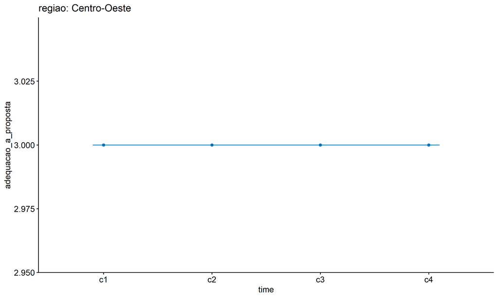

```r
emms.gg <- emms[which(emms$regiao == "Centro-Oeste"),]
if (nrow(emms.gg) > 0)
  ggline(emms.gg, x = "time", y = "emmean", color = "#0073C2FF", ylab = "adequacao_a_proposta") +
    geom_errorbar(aes(ymin = conf.low, ymax = conf.high),
                  width = 0.2, color = "#0073C2FF") +
    stat_pvalue_manual(
      add_xy_position(pwc[which(pwc$regiao == "Centro-Oeste"),],
                      x = "time", fun = "mean_se"),
      hide.ns = T, color = "#0073C2FF", tip.length = F) +
    labs(title = "regiao: Centro-Oeste")+
    theme(legend.text = element_blank())
```